# 6. ARIMA Modeling

# (6-2) B-J DIFFERENCING

[Nao Mimoto](https://nmimoto.github.io/) - [Dept. of Statistics](http://www.uakron.edu/stat/) : [The University of Akron](http://www.uakron.edu)

[TS Class Web Page](https://nmimoto.github.io/477/) – [R resource page](https://nmimoto.github.io/R/)

# 1. Box-Jenkins Differencing Method

This is called ARIMA modeling.

## a) Backward and Difference Operator

- Recall the backward operator $B$,
  $$B \, X_t = X_{t-1}.$$
- Then define **difference operator** $\bigtriangledown$ (del),
  $$\bigtriangledown = (1-B).$$
- For example,
  $$\bigtriangledown X_t = (1-B)X_t = X_t - X_{t-1} \\ \\
  \bigtriangledown^2 X_t = (1-B)(1-B) X_t = X_t - 2X_{t-1} + X_{t-2}$$

## b) Differencing Linear Trend

- Suppose your time series have a line plus a zero-mean staionary noise.
  $$Y_t = a + bt + X_t$$
  That means
  $$Y_{t-1} = a + b(t-1) + X_{t-1} \\ \\
  \bigtriangledown Y_t = Y_t - Y_{t-1} = b + X_t - X_{t-1}$$
- If $X_t$ is stationary, then $X_t-X_{t-1}$ is also stationary. Thus we have now
  $$\bigtriangledown Y_t = \mu + M_t$$
  We can try to model this with ARMA(p,q) with intercept $\mu = b$.

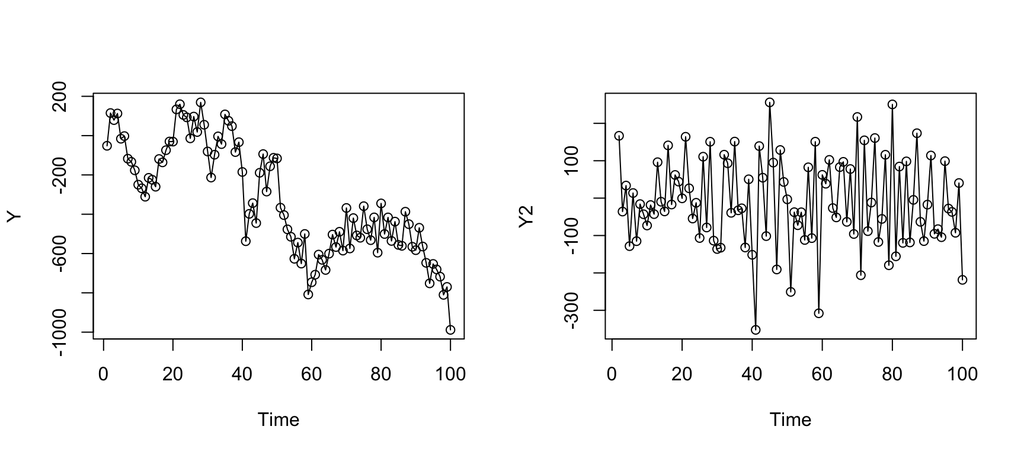

```r
  set.seed(42352)
  t   <- 1:100
  Y   <- 3 - 10*t + arima.sim(n=100, list(ar = c(.7,.2)), sd=100)

  Y2 <- diff(Y)              # take the difference

  layout(matrix(1:2,1,2))
  plot(Y,type="o")           # Y is simulated data
  plot(Y2, type="o" )
```

```r
  mean(Y2)
```

```
## [1] -9.461098
```

## c) Differencing Quadratic Trend

- If $m_t$ is quadratic, then
  $$\begin{align}
  Y_t &= a + bt + c t^2 + X_t \\\\
  Y_{t-1} &= a + b(t-1) + c (t-1)^2+ X_{t-1} \\\\
  Y_{t-2} &= a + b(t-2) + c (t-2)^2 + X_{t-2}.
  \end{align}$$

  That means

  $$\begin{align}
  \bigtriangledown^2 Y_t
  &= Y_t - 2Y_{t-1} + Y_{t-2} \\\\
  &= 2c + X_t - 2X_{t-1} + X_{t-2}
  \end{align}$$

  If $X_t$ is stationary, so is $X_t - 2X_{t-1} + X_{t-2}$.
- If $m_t$ is polynomial of deg $k$, with coefficients $c_0, c_1, $ then applying $k$ power of difference operator will remove the trend.
  $$\bigtriangledown^k Y_t = k! c_k + \bigtriangledown^k X_t.$$
- Then you will end up with some statonary series $\bigtriangledown^k X_t$ with constant trend $k! c_k$.

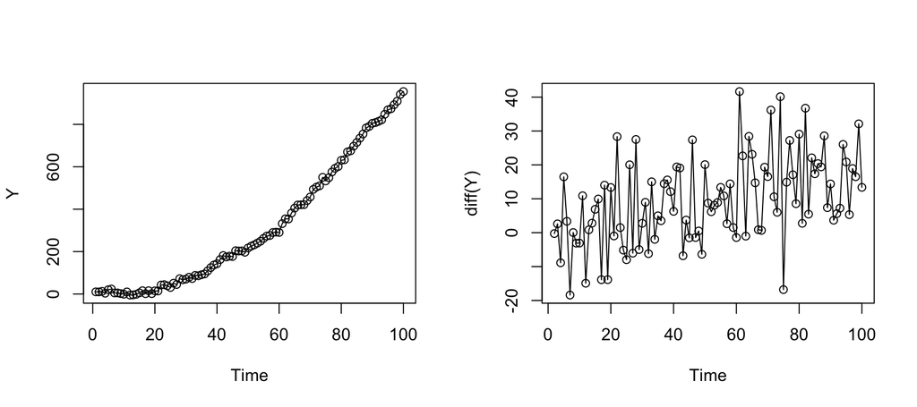

```r
  t   <- 1:100
  tsq <- t^2
  Y   <- 3 - .5*t + .1*tsq + arima.sim(n=100, list(ar = c(.7,.2)))*10

  layout(matrix(1:2, 1, 2))
  plot(Y,type="o")
  plot(diff(Y),type="o")
```

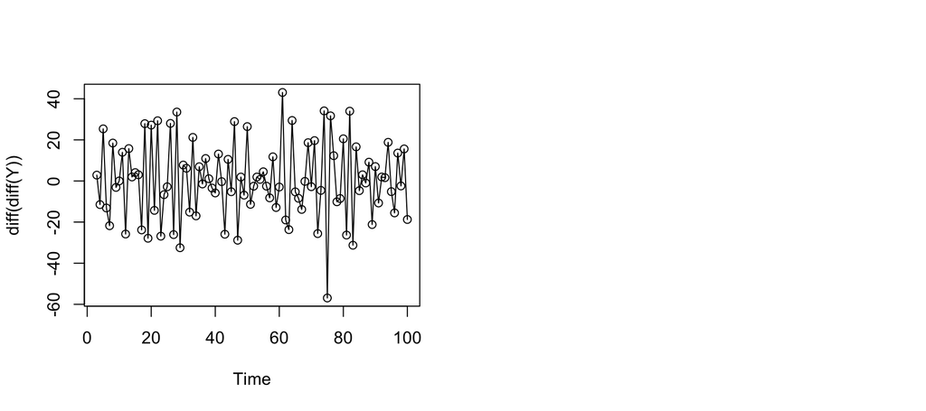

```r
  plot(diff(diff(Y)),type="o")
```

#### Box-Jenkins Differencing Turns many non-stationary trends into stationary.

#### If you difference linar trend $a+bt$ once, it becomes constant trend $b$.

#### If you difference quadratic trend $a+bt+ct^2$ twice, it becomes constant trend $2c$.

# 2. Difference on Random Trends

## a) Random Walk

- Suppose we have a model with random trend
  $$Y_t = M_t + X_t,$$
  where $X_t$ is a stationary series and $M_t$ is a random walk:
  $$M_t = \sum_{i=1}^t e_i \mbox{ where } e_i \sim_{iid} N(0, 1).$$
- With iid errors $(e_1,e_2,e_3,\ldots)$ random walk is generated as

  $$\begin{align}
  M_1 &= e_1 \\
  M_2 &= e_1 + e_2 \\
  M_3 &= e_1 + e_2 + e_3 \\
  M_4 &= e_1 + e_2 + e_3 + e_4 \\
  &\vdots
  \end{align}$$
- We can use **cumsum()** function in R to do this easily.
- Mean of RW is
  $$E[M_t] = E\Big(\sum_{i=1}^t e_i\Big) =
  \sum_{i=1}^t E(e_i) = 0$$
- Variance of RW is
  $$V[M_t] = V\Big(\sum_{i=1}^t e_i\Big) =
  \sum_{i=1}^t V(e_i) = \sigma^2 t$$

### Example: Simulate RW

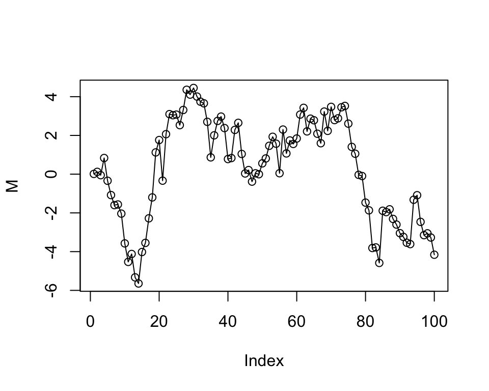

```r
  #- RW without drift
  e = rnorm(100)      #- 100 random number from N(0,1)
  M = cumsum(e)
  plot(M,type="o")
```

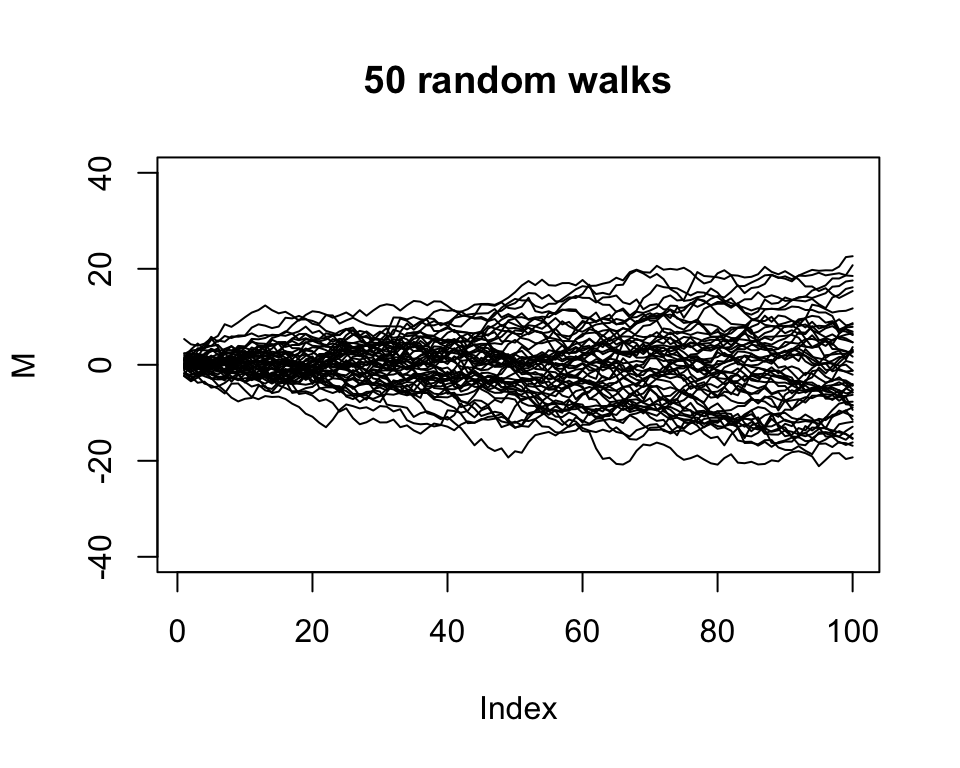

```r
  #- repeat this 50 times
  plot(M,type="l", ylim=c(-40,40), main="50 random walks")
  for (i in 1:50) {
    e = rnorm(100)      #- copy and paste these 3 lines many times
    M = cumsum(e)
    lines(M)
  }
```

- Note that mean is 0, but variance increase as time goes on.

## b) Differencing Random Walk

- Since
  $$M_t = \sum_{i=1}^t e_i,$$
  we have
  $$\bigtriangledown M_t =
  M_t - M_{t-1} = \sum_{i=1}^t e_i - \sum_{i=1}^{n-1} e_i
  = e_t$$
- And we know that $e_t \sim N(0,\sigma)$.
- So if $M_t$ is Random Walk, then $\bigtriangledown M_t$ should look like iid $N(0,\sigma)$ noise.

### Example: Random Walk

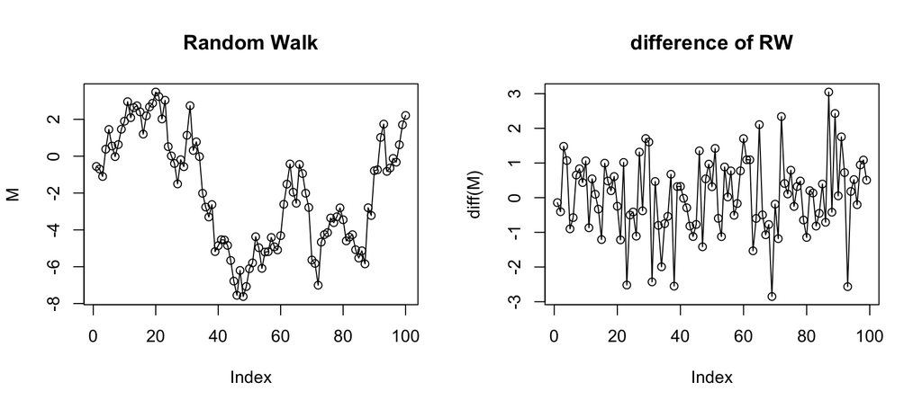

```r
  e = rnorm(100)      #- 100 random number from N(0,1)
  M = cumsum(e)

  layout(matrix(1:2, 1, 2))
  plot(M,type="o", main="Random Walk")
  plot(diff(M), type="o", main="difference of RW");
```

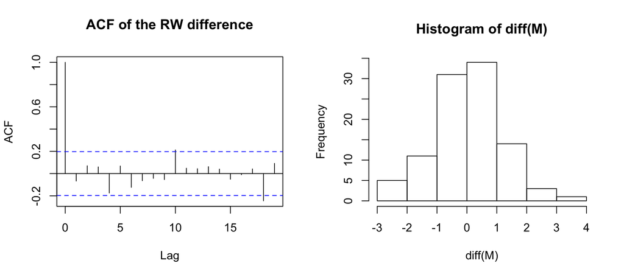

```r
  acf(diff(M), main="ACF of the RW difference")
  hist(diff(M))
```

## c) Random Walk with Drift

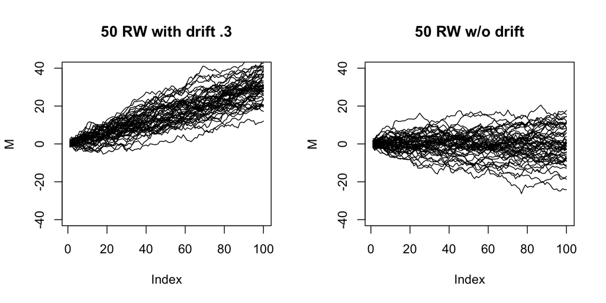

```r
  layout(matrix(1:2, 1, 2))

  #- RW with drift (delta = .3)
  e = rnorm(100, .3, 1)      #- 100 random number from N(1,1)
  M = cumsum(e)

  #- repeat this 50 times
  plot(M,type="l", ylim=c(-40,40), main="50 RW with drift .3")
  for (i in 1:50) {
    e = rnorm(100, .3, 1)
    M = cumsum(e)
    lines(M)
  }


  #- RW without drift
  e = rnorm(100)      #- 100 random number from N(0,1)
  M = cumsum(e)

  #- repeat this 50 times
  plot(M,type="l", ylim=c(-40,40), main="50 RW w/o drift")
  for (i in 1:50) {
    e = rnorm(100)      #- copy and paste these 3 lines many times
    M = cumsum(e)
    lines(M)
  }
```

## d) Testing Random Walk for Drift

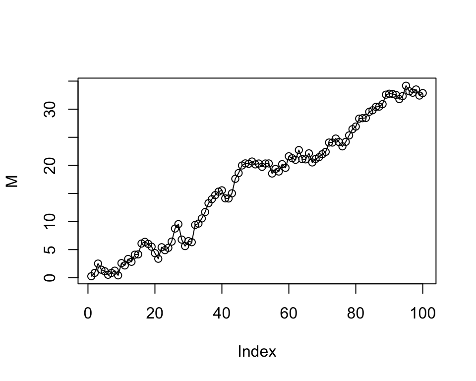

```r
  set.seed(87656)

  e = rnorm(100, .3, 1)
  M = cumsum(e)

  plot(M,type="o")
```

- Does this RW has drift or not?
- Test if mean of the difference is 0.

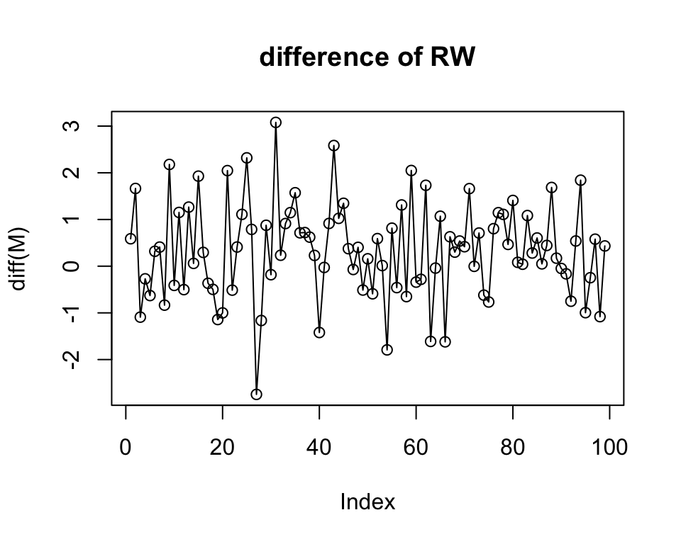

```r
  plot(diff(M), type="o", main="difference of RW")
```

```r
  c(mean(diff(M)), sd(diff(M)), 1.96*sd(diff(M))/sqrt(100) )
```

```
## [1] 0.3292302 1.0239543 0.2006950
```

- 95% CI for the mean is $.33 \pm .20$, so the sample mean is significantly different from 0. We conclude that the above RW has a drift.

### Random Walk as Trend

- If $Y_t = M_t + X_t$, then
  $$Y_t = \sum_{i=1}^t e_i + X_t
  \\Y_{t-1} = \sum_{i=1}^{t-1} e_i + X_{t-1}$$
  That means
  $$\bigtriangledown Y_t = Y_t - Y_{t-1}
  = e_t + X_t - X_{t-1}$$
  Since $X_t, e_t$ are stationary, so is $e_t+X_t-X_{t-1}$.

#### If you difference Random Walk without drift once, it becomes N($0,\sigma^2$) iid noise.

#### If you difference Random Walk with drift $\delta$ once, it becomes N($\delta,\sigma^2$) iid noise.

## Ex1: Temperature Data

Global temparature data from Shumway

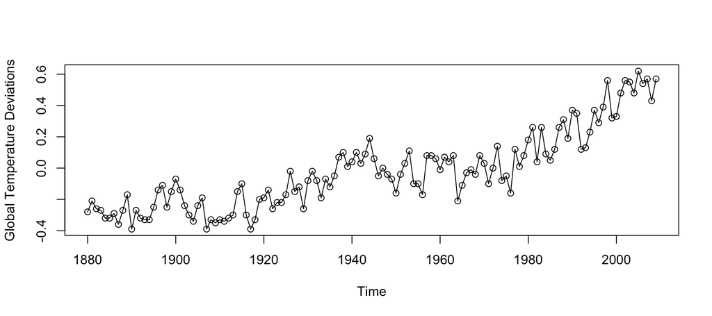

```r
  library(astsa)
  data(gtemp)

  plot(gtemp, type="o", ylab="Global Temperature Deviations")
```

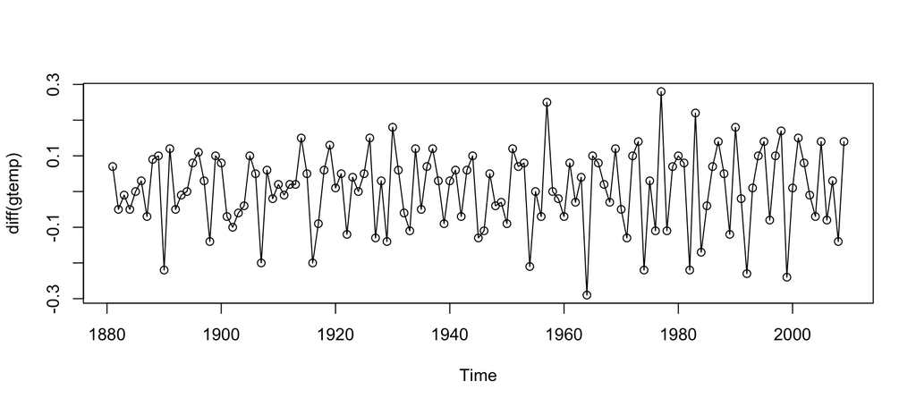

```r
  plot(diff(gtemp), type="o")
```

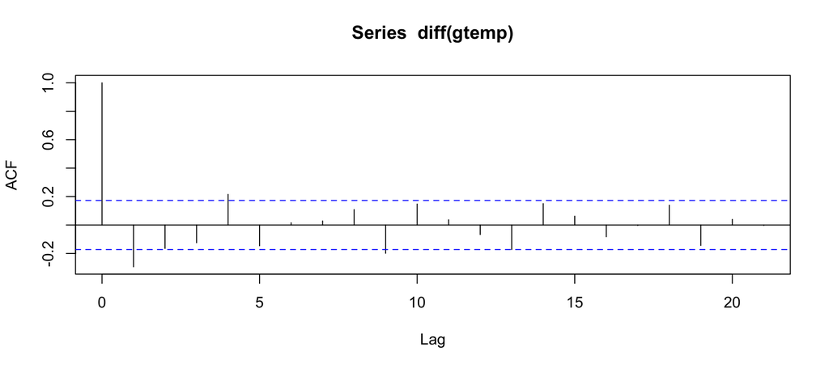

```r
  acf(diff(gtemp))
```

- We want to model the difference of temparature data with ARMA. (ARIMA(p,1,q))

## Ex2: AAPL

Daily adjusted close price of Apple, Inc. Between 10/17/2007 to 8/4/2008 from Yahoo! finance website

```r
  library(quantmod)      # Do install.packages("quantmod")  if not installed

  getSymbols("AAPL")     #- download from Yahoo!
```

```
## [1] "AAPL"
```

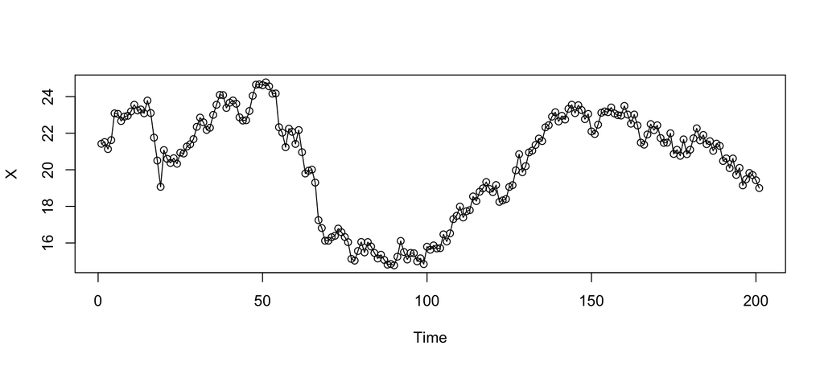

```r
  X <- as.ts(AAPL$AAPL.Adjusted[400:200])
  plot(X, type="o")
```

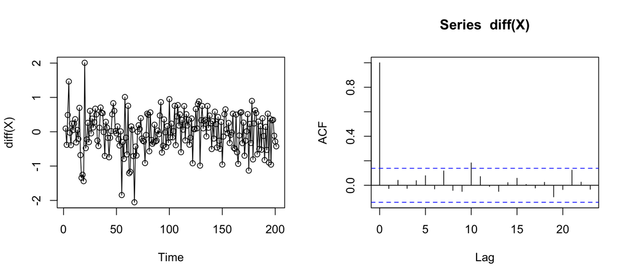

```r
  layout(matrix(1:2, 1, 2))
  plot(diff(X), type="o")
  acf(diff(X))
```

# Summary

#### Box-Jenkins Differencing Turns many non-stationary trends into stationary.

#### If you difference linar trend $a+bt$ once, it becomes constant trend $b$.

#### If you difference quadratic trend $a+bt+ct^2$ twice, it becomes constant trend $2c$.

#### If you difference Random Walk without drift once, it becomes N($0,\sigma^2$) iid noise.

#### If you difference Random Walk with drift $\delta$ once, it becomes N($\delta,\sigma^2$) iid noise.

[TS Class Web Page](https://nmimoto.github.io/477/) – [R resource page](https://nmimoto.github.io/R/)